# Interpretable Machine Learning

June 7, 2018

A client wants you to predict data scientist salaries with machine learning.

## Let’s predict data scientist salaries

## What is Machine Learning?

## Step 1: Find some data

## Step 1: Find some data

Kaggle conducted an industry-wide survey of data scientists. https://www.kaggle.com/kaggle/kaggle-survey-2017

Information asked:

- Compensation
- Demographics
- Job title
- Experience
- …

Contains information from Kaggle ML and Data Science Survey, 2017, which is made available here under the Open Database License (ODbL).

## Step 2: Throw ML on your data

## Step 3: Profit

Client: “There is a problem with the model!”

“What problem?”

Client: “The older the candidates, the higher the predicted salaries.”

Looking inside the black box

## How do the features influence my predictions?

## Partial Dependence Plot

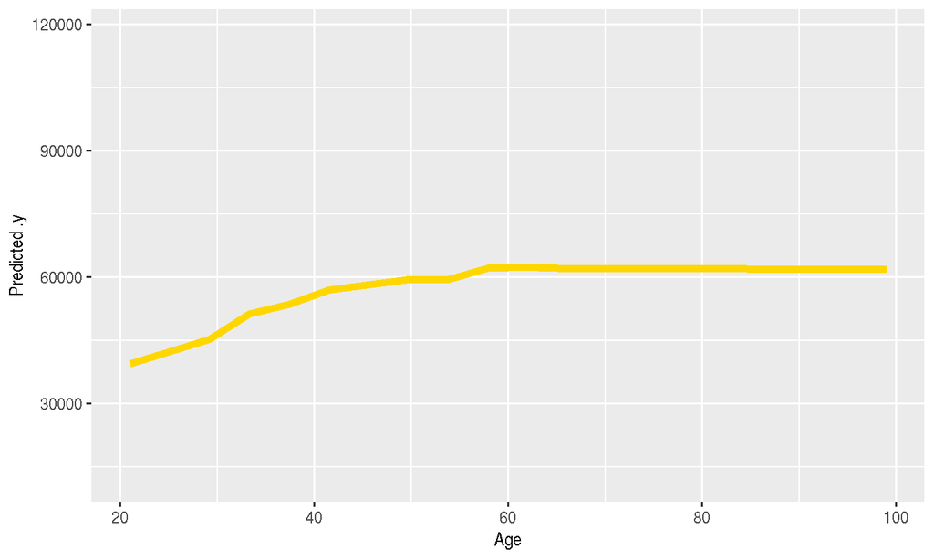

Goldstein, A., Kapelner, A., Bleich, J., & Pitkin, E. (2013). Peeking Inside the Black Box: Visualizing Statistical Learning with Plots of Individual Conditional Expectation, 1–22. https://doi.org/10.1080/10618600.2014.907095

Friedman, J. H. (1999). Greedy Function Approximation : A Gradient Boosting Machine. North, 1(3), 1–10. https://doi.org/10.2307/2699986

Client: “We want to understand the model better!”

## What are the most important features?

## Permutation feature importance

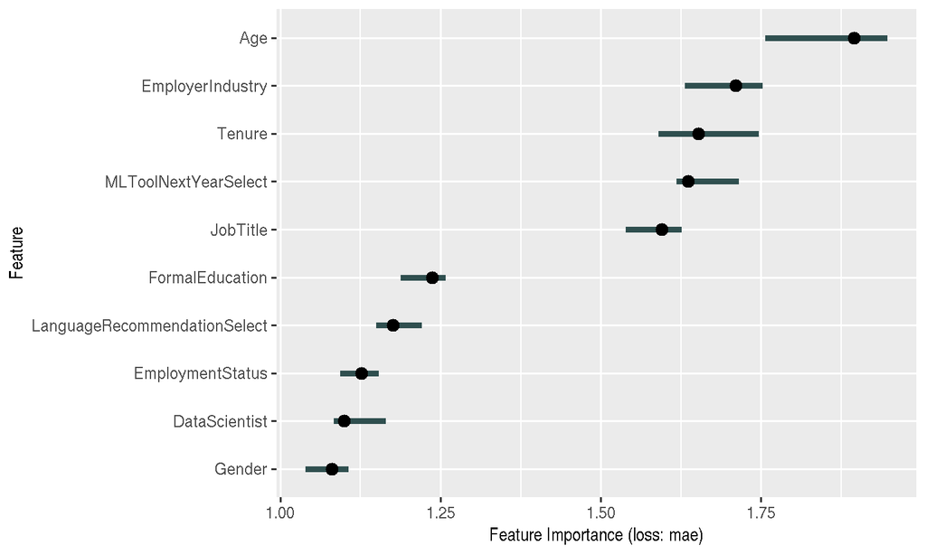

Breiman, Leo. “Random forests.” Machine learning 45.1 (2001): 5-32.

## Gender?!

## What’s the influence of gender on the prediction?

| Gender | .y.hat |
| --- | --- |
| Male | 50564.82 |
| Female | 47168.67 |
| Non-binary, genderqueer, or gender non-conforming | 49904.63 |
| A different identity | 49589.76 |

## Explaining individual predictions

## Local Models (LIME)

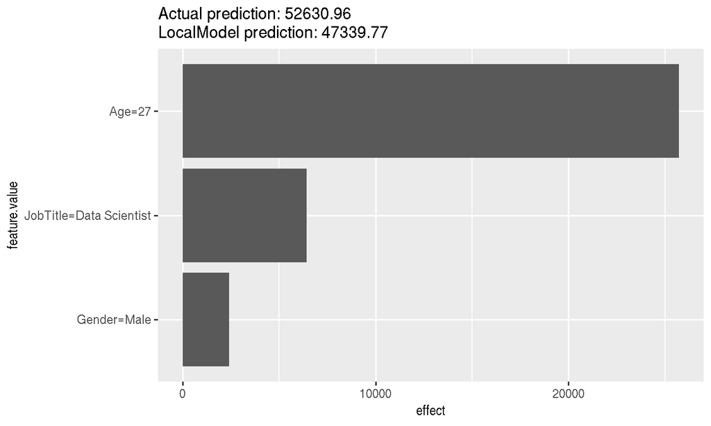

Ribeiro, M. T., Singh, S., & Guestrin, C. (2016). “Why Should I Trust You?”: Explaining the Predictions of Any Classifier. Retrieved from http://arxiv.org/abs/1602.04938

## Some Theory

## The Problem

[figure not shown]

## When do we need interpretability?

## When do we NOT need interpretability?

## What tools do we have?

## Interpretable Models

[figure not shown]

## Interpretable Models

[figure not shown]

## Model-specific methods

[figure not shown]

## Model-specific methods

[figure not shown]

## Model-agnostic methods

[figure not shown]

## Model-agnostic methods

[figure not shown]

## Example-based methods

[figure not shown]

## Example-focused methods

[figure not shown]

## Interested in learning more?

Read my book about “Interpretable Machine Learning” https://christophm.github.io/interpretable-ml-book/

[figure not shown]

## Backup slides

## What is interpretability?

## Statistical Modeling: The Two Cultures

## What makes an explanation human-friendly?

## Shapley Value

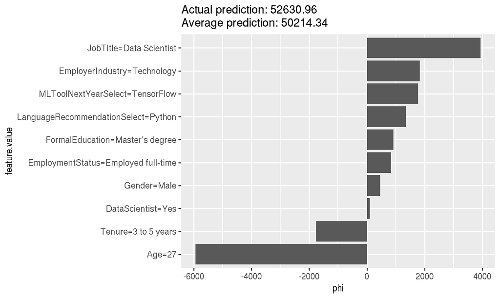